# Were some questions answered by more experienced workers?

Christian Medeiros Adriano

May 12, 2017

### The goal of the study

Distribution of worker skill level across questions has the potential to bias the outcomes of the larger crowdsourcing task. The reason is that software faults can be overlooked if they are covered by questions* that were mostly answered by lower skill workers.

*Each question covers a certain number of source code lines. Questions have the following format:“Do you believe the source code between lines 35 and 45 is related to the described failure?”

Therefore, my goal is to investigate how worker skill level is distributed across questions. Worker skill level was measured by the following three attributes.

Test score: workers received a score (zero to five) after performing a computer programming test used to filter out workers without enough programming knowledge. Workers who scored 2 or less were not allowed to participate.

Years of programming experience: Worker quality can also be measured by years of programming experience, which is an information self-declared by workers befote they take any test.

Profession: worker profession is also an indicator of quality. Professions consisted of professional programmers, hobbyists, graduate students, undergraduate students, and others.

### Focus of the current analysis

The current analysis focuses only on the **worker´s years of experience**.

First let’s see how the workers are distributed in terms of years of experience.

```
##  years_of_experience     worker
##  Min.   : 0.000      Min.   :1
##  1st Qu.: 2.000      1st Qu.:1
##  Median : 5.000      Median :1
##  Mean   : 7.749      Mean   :1
##  3rd Qu.:10.000      3rd Qu.:1
##  Max.   :50.000      Max.   :1
```

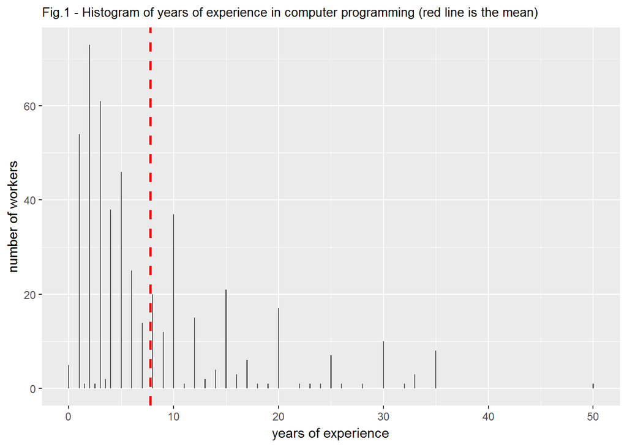

We can obsreve that workers concentrated their information on multiples of 5 and 10.

Since the distribution is very skewed (to the right in this case), the average is not a good representation of the data. The alterantive in these cases is to look at the quartiles, which are shown in the boxplot below.

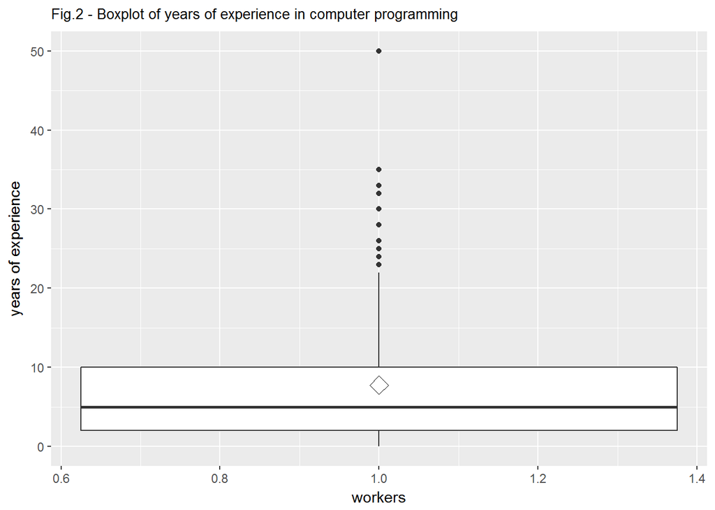

```
##    Min. 1st Qu.  Median    Mean 3rd Qu.    Max.
##   0.000   2.000   5.000   7.749  10.000  50.000
```

Bloxplot shows that half of the data points are bewlo 5 years of experience. 25% are between 5 and 10 years of experience.

Therefore, in order to investigate the distribute of years of experience across questions, I selected the following four intervals: below 2 years, from 2 to 5 years, from 5 to 10, and above 10 years of experience.

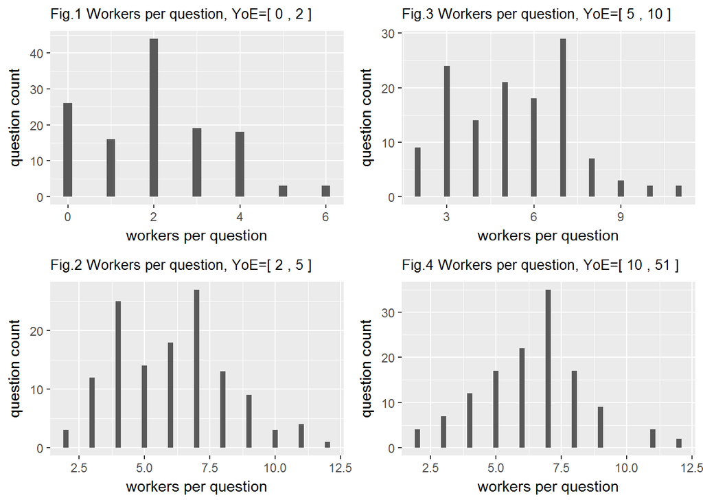